# Practice2

```python
import pandas as pd
import numpy as np

import seaborn as sns
import matplotlib.pyplot as plot
```

```python
df = pd.read_csv("vgsales_22.csv")
```

После определения библиотек и загрузки датасета рисуем первый график - график количества значений категориального атрибута.

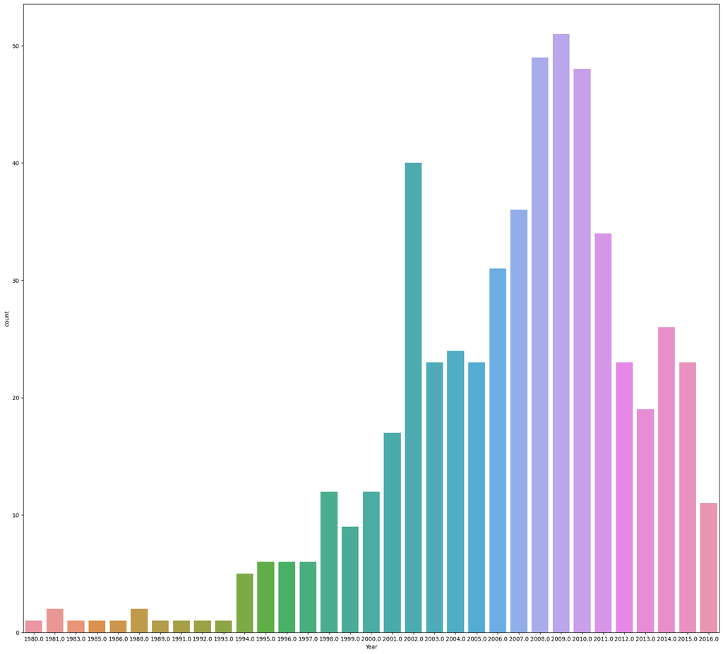

```python
graph = sns.countplot(x="Year", data = df)
graph.figure.set_figwidth(22)
graph.figure.set_figheight(20)
```

График количества значений категориального атрибута используется в статистике для визуализации распределения данных внутри категорий. Категориальный атрибут представляет собой переменную, которая принимает ограниченное количество дискретных значений или категорий.

Создание графика количества значений категориального атрибута помогает в следующих случаях:  
1. Исследование распределения  
2. Сравнение категорий  
3. Выявление выбросов  
4. Визуализация паттернов  
5. Поддержка принятия решений

Далее идет график среднего значения атрибутов.

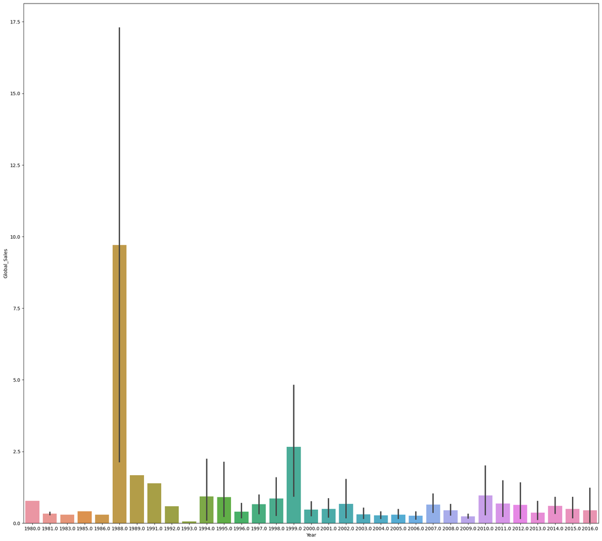

```python
graph = sns.barplot(x=df["Year"], y=df["Global_Sales"])
graph.figure.set_figwidth(22)
graph.figure.set_figheight(20)
```

В принципе ничего сложного, в нем определены средние значения глобальных продаж игр по годам выпуска игр.

Далее просто смотрим на распределение данных относительно лет выпуска (нет в тз, но просто ради интереса тогда).

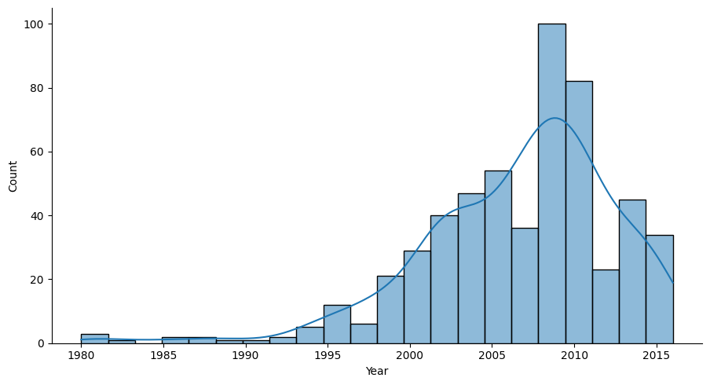

```python
graph = sns.displot(df["Year"], kde = True)
graph.figure.set_figwidth(10)
graph.figure.set_figheight(5)
```

Ящики с усами.  
Используется для просмотра квартилей, определения разброса и асимметри данных (тоже самое, что и в математике, мы рассматриваем отклонения, которые будут отображать искажения или особенности данных).

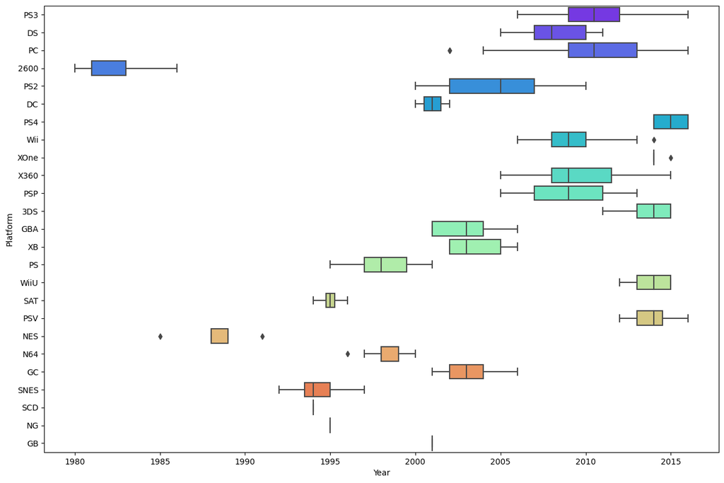

```python
graph = sns.boxplot(x="Year", y="Platform",data = df,palette='rainbow')
graph.figure.set_figwidth(15)
graph.figure.set_figheight(10)
```

Теперь требуется сделать корреляцию данных  
(Она позволяет определить, насколько сильно и в каком направлении связаны данные переменные. 1 - данные прямо пропорционально связаны, -1 - обратно пропорциональны, 0 - нет связи между данными.)  
Для этого убираем все значения, которые нельзя неявно конвертировать в число с плавающей точкой.

```python
df1 = df
df1 = df1.drop("Name", axis=1)
df1 = df1.drop("Platform", axis=1)
df1 = df1.drop("Genre", axis=1)
df1 = df1.drop("Publisher", axis=1)
```

```python
df1
```

|  | Rank | Year | NA_Sales | EU_Sales | JP_Sales | Other_Sales | Global_Sales |
| --- | --- | --- | --- | --- | --- | --- | --- |
| 0 | 14378 | 2014.0 | 0.00 | 0.00 | 0.03 | 0.00 | 0.03 |
| 1 | 14260 | 2006.0 | 0.03 | 0.00 | 0.00 | 0.00 | 0.03 |
| 2 | 9891 | 2013.0 | 0.00 | 0.10 | 0.00 | 0.02 | 0.12 |
| 3 | 5958 | 1986.0 | 0.28 | 0.02 | 0.00 | 0.00 | 0.29 |
| 4 | 7095 | 2008.0 | 0.11 | 0.09 | 0.00 | 0.03 | 0.23 |
| ... | ... | ... | ... | ... | ... | ... | ... |
| 548 | 8560 | 2005.0 | 0.00 | 0.00 | 0.16 | 0.00 | 0.16 |
| 549 | 3815 | 2008.0 | 0.48 | 0.01 | 0.00 | 0.04 | 0.53 |
| 550 | 2718 | 2014.0 | 0.24 | 0.46 | 0.00 | 0.06 | 0.76 |
| 551 | 1093 | 2001.0 | 0.59 | 0.95 | 0.03 | 0.10 | 1.67 |
| 552 | 967 | 2010.0 | 1.41 | 0.21 | 0.03 | 0.16 | 1.80 |

553 rows × 7 columns

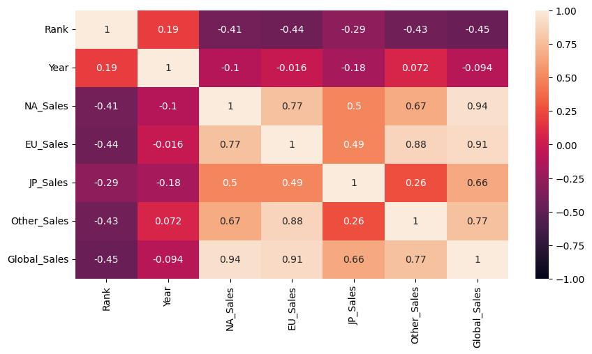

```python
MyHeatMap = sns.heatmap(df1.corr(), vmin=-1, vmax=1, annot=True)
MyHeatMap.figure.set_figwidth(10)
MyHeatMap.figure.set_figheight(5)
```

Теперь строим матрицу рассеивания, которая будет показывть соотношения между атрибутами.  
По сути, нового ничего нет, потому что мы работаем с одинаковыми данными и рассматриваем соотношения атрибутов между собой и особенности данных. Поэтому тут можно заметить очень похожий график на пересечении атрибутов Year и Global_Sales на тот, что был выше несколькими. Далее идет Pairgrid, что, по сути, тоже самое.

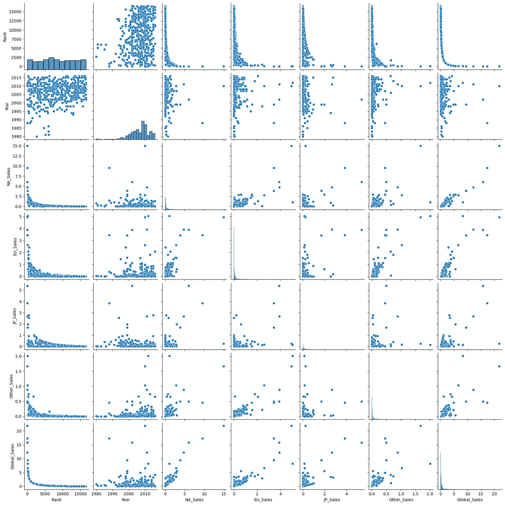

```python
graph = sns.pairplot(df)
```

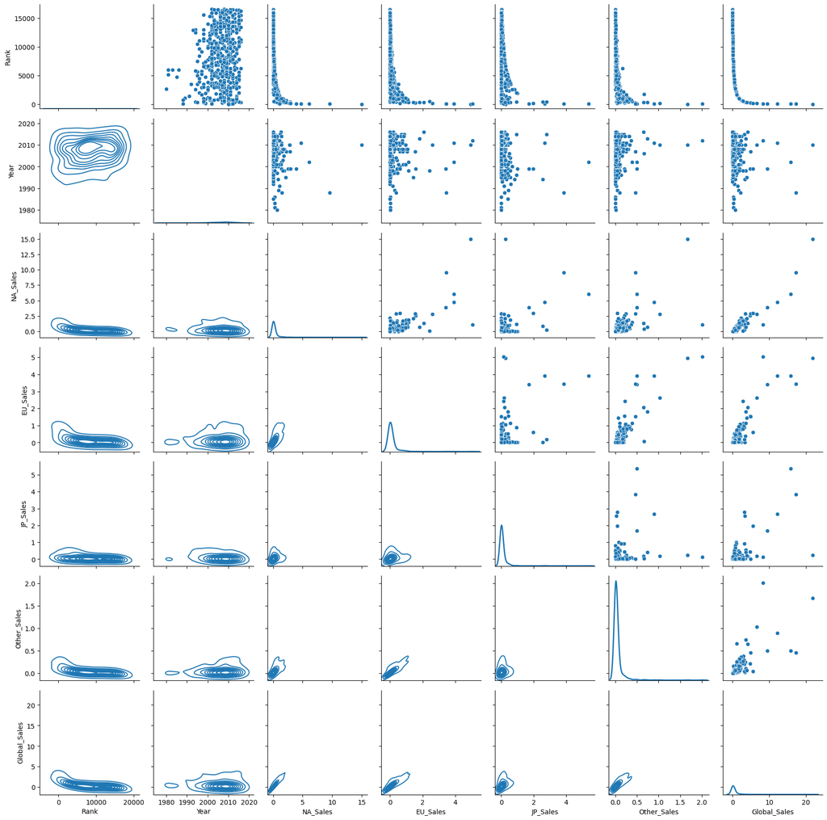

```python
graph = sns.PairGrid(df)
graph = graph.map_upper(sns.scatterplot)
graph = graph.map_lower(sns.kdeplot)
graph = graph.map_diag(sns.kdeplot, lw = 2)
```

Переходим к кластеризации - поиска схожестей в выборке данных.  
Очень похоже на корреляцию, но немного подругому.

```python
df_claster = df[["NA_Sales","EU_Sales","JP_Sales"]][::50]
df_claster
```

|  | NA_Sales | EU_Sales | JP_Sales |
| --- | --- | --- | --- |
| 0 | 0.00 | 0.00 | 0.03 |
| 50 | 0.21 | 0.19 | 0.00 |
| 100 | 0.08 | 0.00 | 0.00 |
| 150 | 0.00 | 0.00 | 0.02 |
| 200 | 2.18 | 0.01 | 0.00 |
| 250 | 0.06 | 0.04 | 0.00 |
| 300 | 0.04 | 0.01 | 0.00 |
| 350 | 0.00 | 0.00 | 0.20 |
| 400 | 0.02 | 0.00 | 0.00 |
| 450 | 0.26 | 0.21 | 0.11 |
| 500 | 0.25 | 0.39 | 0.00 |
| 550 | 0.24 | 0.46 | 0.00 |

```python
from sklearn.cluster import KMeans

model = KMeans(n_clusters=3)

model.fit(df_claster)

all_predictions = model.predict(df_claster)

df_claster["KMeans"] = all_predictions

df_claster
```

|  | NA_Sales | EU_Sales | JP_Sales | KMeans |
| --- | --- | --- | --- | --- |
| 0 | 0.00 | 0.00 | 0.03 | 2 |
| 50 | 0.21 | 0.19 | 0.00 | 0 |
| 100 | 0.08 | 0.00 | 0.00 | 2 |
| 150 | 0.00 | 0.00 | 0.02 | 2 |
| 200 | 2.18 | 0.01 | 0.00 | 1 |
| 250 | 0.06 | 0.04 | 0.00 | 2 |
| 300 | 0.04 | 0.01 | 0.00 | 2 |
| 350 | 0.00 | 0.00 | 0.20 | 2 |
| 400 | 0.02 | 0.00 | 0.00 | 2 |
| 450 | 0.26 | 0.21 | 0.11 | 0 |
| 500 | 0.25 | 0.39 | 0.00 | 0 |
| 550 | 0.24 | 0.46 | 0.00 | 0 |

После множества исследований переходим к отображению количества значений в каждом кластере. 0 - 4 значения, 1 - 1 значение, 2 - 7 значений.

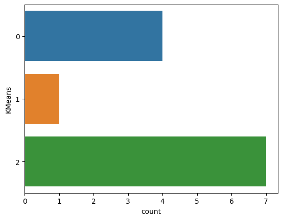

```python
sns.countplot(data = df_claster, y = "KMeans")
```

Далее есть улучшенная кластеризация, я немного в этом понимаю, поэтому так сухо.

```python
from sklearn.cluster import DBSCAN

model = DBSCAN()

model.fit(df_claster)

df_claster["DBSCAN"] = model.labels_

df_claster
```

|  | NA_Sales | EU_Sales | JP_Sales | KMeans | DBSCAN |
| --- | --- | --- | --- | --- | --- |
| 0 | 0.00 | 0.00 | 0.03 | 2 | 0 |
| 50 | 0.21 | 0.19 | 0.00 | 0 | -1 |
| 100 | 0.08 | 0.00 | 0.00 | 2 | 0 |
| 150 | 0.00 | 0.00 | 0.02 | 2 | 0 |
| 200 | 2.18 | 0.01 | 0.00 | 1 | -1 |
| 250 | 0.06 | 0.04 | 0.00 | 2 | 0 |
| 300 | 0.04 | 0.01 | 0.00 | 2 | 0 |
| 350 | 0.00 | 0.00 | 0.20 | 2 | 0 |
| 400 | 0.02 | 0.00 | 0.00 | 2 | 0 |
| 450 | 0.26 | 0.21 | 0.11 | 0 | -1 |
| 500 | 0.25 | 0.39 | 0.00 | 0 | -1 |
| 550 | 0.24 | 0.46 | 0.00 | 0 | -1 |

Далее такая же диаграмма только с данными по DBSCAN, да, там нет значения единицы.

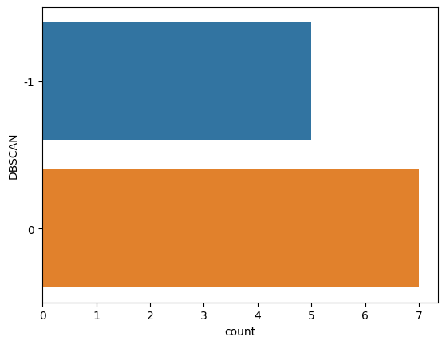

```python
sns.countplot(data = df_claster, y = "DBSCAN")
```

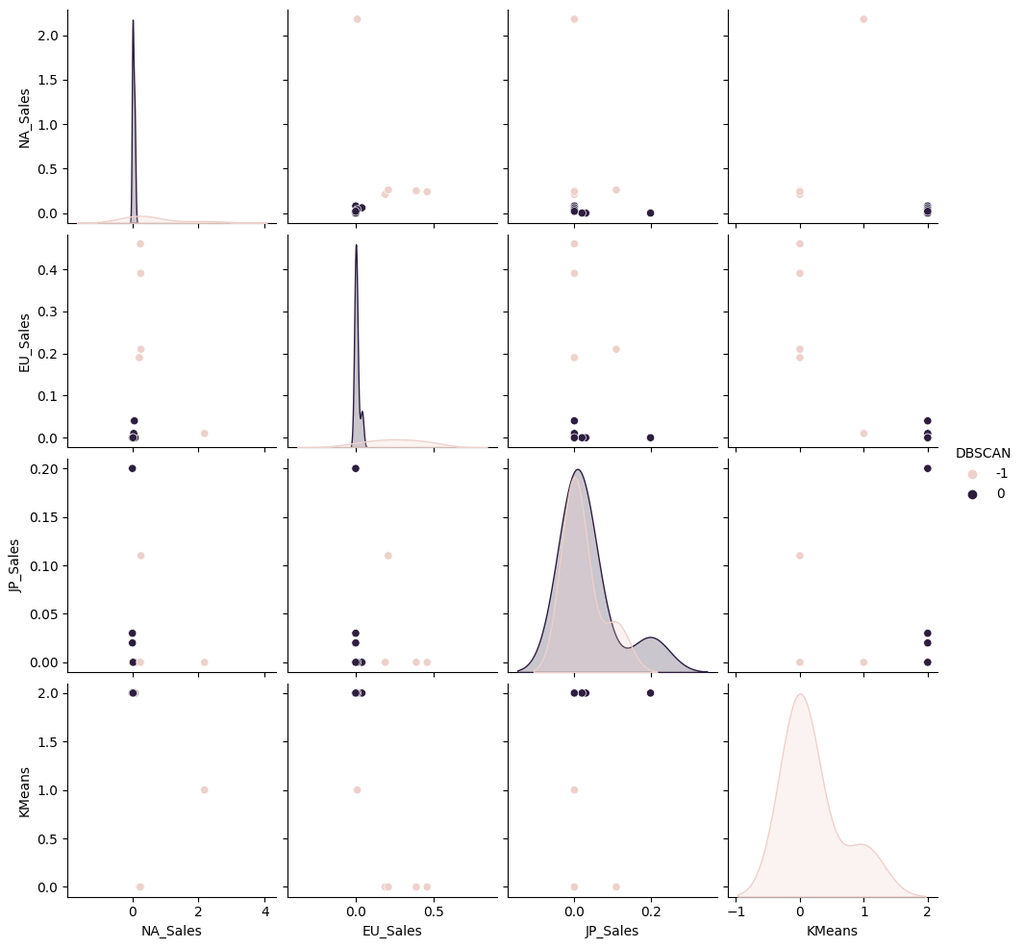

```python
sns.pairplot(df_claster[::1],hue="DBSCAN")
```

В коце мы совместили матрицу рассеивания с кластеризацией.  
Так мы завершили практическую работу. В результате которой мы изучили построение графиков по огромной выборке, изучили новые термины и попробовали всё на личном опыте.